# NLP_Final2_Topics

## NLP Class Final Project: Topic Modeling (LDA)

### Tsengee Sundui

```python
import pandas as pd
import re
import nltk as nltk
import numpy as np
import matplotlib.pyplot as plt
import seaborn as sns
import spacy
import time
import math
import string
import gensim
import pyLDAvis
import seaborn as sns
import matplotlib.pyplot as plt

from textblob import TextBlob
from nltk.corpus import stopwords
from nltk.stem.wordnet import WordNetLemmatizer
from gensim import corpora, models
from gensim.models.ldamulticore import LdaMulticore
```

```python
import pandarallel
import multiprocessing
from pandarallel import pandarallel

num_processors = multiprocessing.cpu_count()

pandarallel.initialize(nb_workers=num_processors, use_memory_fs=False)
```

```
INFO: Pandarallel will run on 12 workers.
INFO: Pandarallel will use standard multiprocessing data transfer (pipe) to transfer data between the main process and workers.

WARNING: You are on Windows. If you detect any issue with pandarallel, be sure you checked out the Troubleshooting page:
https://nalepae.github.io/pandarallel/troubleshooting/
```

### Load pre-processed data

```python
%%time

input_path = r"C:\Users\sundu\OneDrive - The University of Chicago\Documents\Autumn 2023\NLP/cleaned_data1.parquet"
df = pd.read_parquet(input_path, engine='pyarrow')
```

```
CPU times: total: 2.8 s
Wall time: 14.1 s
```

```python
df.head()
```

|  | date | clean_title | clean_text |
| --- | --- | --- | --- |
| 0 | 2020-02-26 | LegalTech Artificial Intelligence Market 2019 ... | LegalTech Artificial Intelligence Market Techn... |
| 1 | 2021-07-05 | Observation, Simulation, And AI Join Forces To... | AI Join Forces Reveal Clear Universe SpaceRef ... |
| 2 | 2020-02-23 | Artificial intelligence yields new antibiotic ... | Artificial intelligence yield new antibiotic U... |
| 3 | 2021-03-26 | Forget ML, AI and Industry 4.0 obsolescence sh... | Forget AI Industry obsolescence focus February... |
| 4 | 2023-07-21 | How You Should Validate Machine Learning Model... | Validate Machine Learning Models Patryk PhD NE... |

```python
df.shape
```

```
(138841, 3)
```

```python
# Randomly sample 10% of the data for faster processing
sampled_df = df.sample(frac=0.1, random_state=42)
sampled_df.shape
```

```
(13884, 3)
```

```python
sampled_df.head(5)
```

|  | date | clean_title | clean_text |
| --- | --- | --- | --- |
| 136612 | 2021-02-20 | Google fires AI manager who protested her peer... | Google fire AI manager protested peer departur... |
| 61116 | 2020-01-13 | HealthLytix Joins Nuance AI Marketplace for Di... | HealthLytix Joins Nuance AI Marketplace Diagno... |
| 2320 | 2020-08-27 | Healthcare Artificial Intelligence AI Market W... | Healthcare Artificial Intelligence AI Market W... |
| 37720 | 2023-04-13 | ChatGPT could return to Italy if OpenAI compli... | ChatGPT could return Italy OpenAI complies rul... |
| 115127 | 2023-03-13 | Business News UCCIL Lauds Mahima Mishras Entre... | Business News UCCIL Lauds Mahima Mishras Entre... |

### Detect major topics

```python
Lda = gensim.models.ldamodel.LdaModel
```

```python
sampled_df['combined_text'] = sampled_df['clean_title'] + ' ' + sampled_df['clean_text']

sampled_df['combined_text'] = sampled_df['combined_text'].str.lower()
sampled_df['combined_tokens'] = sampled_df['combined_text'].apply(lambda text: text.split())
# Create a dictionary and a corpus
dictionary1 = corpora.Dictionary(sampled_df['combined_tokens'])
corpus1 = [dictionary1.doc2bow(text) for text in sampled_df['combined_tokens']]
```

```python
from gensim.models import LdaModel
from gensim.models.coherencemodel import CoherenceModel
```

```python
import warnings
warnings.simplefilter('ignore')
start_n = 2
end_n = 15

n_values = range(start_n, end_n + 1)
perplexity_scores1 = []
coherence_scores1 = []

for n in n_values:
    lda_model1 = Lda(corpus=corpus1, num_topics=n, id2word=dictionary1, passes = 50)
    perplexity1 = lda_model1.log_perplexity(corpus1)
    perplexity_scores1.append(perplexity1)

    coherence_model1 = CoherenceModel(model=lda_model1, texts=sampled_df['combined_tokens'], dictionary=dictionary1, coherence='c_v')
    coherence1 = coherence_model1.get_coherence()
    coherence_scores1.append(coherence1)
```

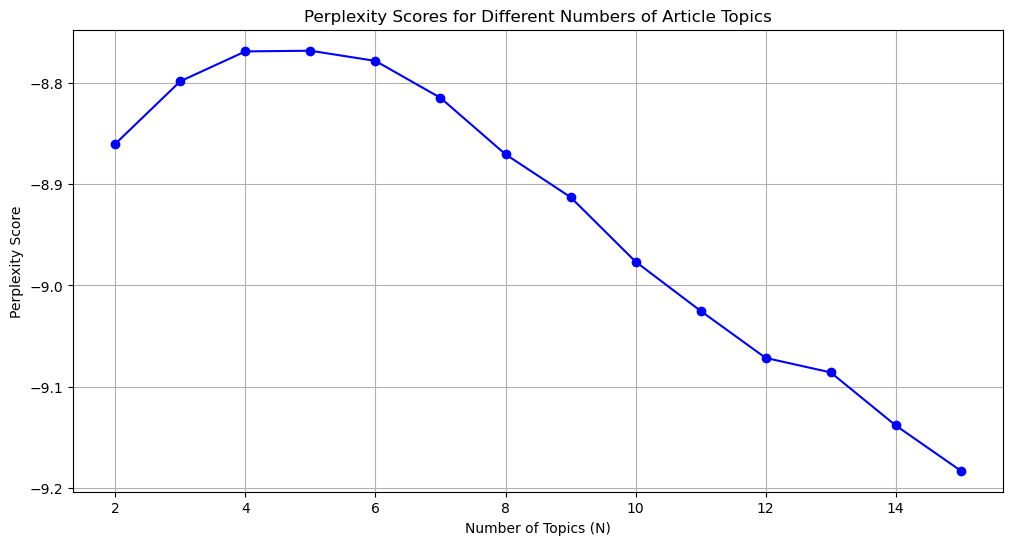

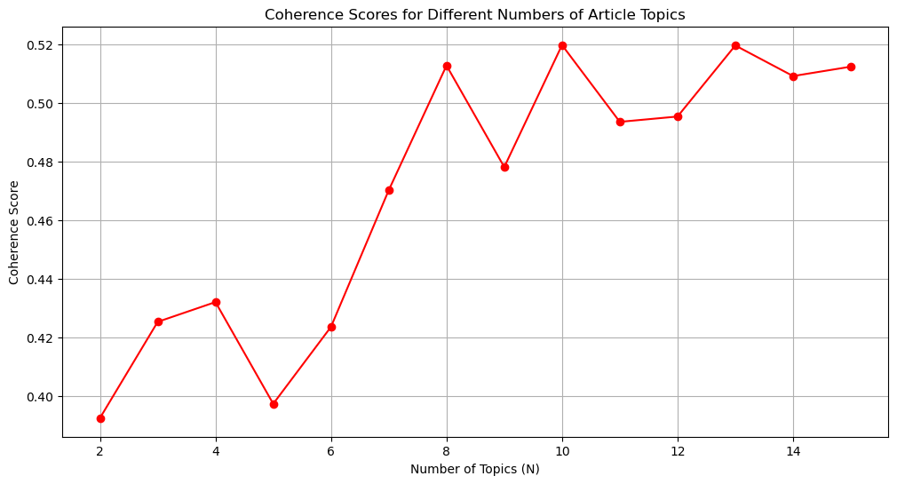

```python
# Plot perplexity scores
plt.figure(figsize=(12, 6))
plt.plot(n_values, perplexity_scores1, marker='o', linestyle='-', color='b')
plt.title('Perplexity Scores for Different Numbers of Article Topics')
plt.xlabel('Number of Topics (N)')
plt.ylabel('Perplexity Score')
plt.grid()

# Plot coherence scores
plt.figure(figsize=(12, 6))
plt.plot(n_values, coherence_scores1, marker='o', linestyle='-', color='r')
plt.title('Coherence Scores for Different Numbers of Article Topics')
plt.xlabel('Number of Topics (N)')
plt.ylabel('Coherence Score')
plt.grid()

plt.show()
```

### Comment:

I calculated and plotted perplexity and coherence scores for different N-values (using the CoherenceModel package) to evaluate the LDA topic model. A lower perplexity score (less negative value) means the topics are more informative. A higher coherence score suggests a better quality of topics. So, I tried choose an N that minimizes perplexity and maximizes coherence.

For the news articles, the optimal N seems to be at 10 topics (coherence peaks and perplexity is lower). 13 topics might be suitable as well, but I'm choosing to go with 10 instead, since the coherence scores are the same and perplexity only goes down a litte.

```python
from gensim import corpora
from gensim.models import LdaModel
from gensim.parsing.preprocessing import preprocess_string

sampled_df['combined_text'] = sampled_df['clean_title'] + ' ' + sampled_df['clean_text']

# Preprocess the text data
def preprocess_text(text):
    return preprocess_string(text)

# Apply preprocessing to the 'combined' column
sampled_df['processed_text'] = sampled_df['combined_text'].apply(preprocess_text)

# Create a dictionary representation of the documents
dictionary = corpora.Dictionary(sampled_df['processed_text'])

# Create a bag-of-words corpus
corpus = [dictionary.doc2bow(text) for text in sampled_df['processed_text']]

# Train the LDA model
num_topics = 10
lda_model = LdaModel(corpus=corpus, id2word=dictionary, num_topics=num_topics, passes=10, random_state=42)

# Print the topics
topics = lda_model.print_topics(num_words=10)
for topic in topics:
    print(topic)
```

```
(0, '0.011*"product" + 0.009*"new" + 0.007*"busi" + 0.007*"public" + 0.007*"servic" + 0.007*"overviewview" + 0.006*"consum" + 0.005*"insur" + 0.005*"industri" + 0.005*"technolog"')
(1, '0.068*"market" + 0.021*"report" + 0.020*"intellig" + 0.018*"artifici" + 0.016*"global" + 0.015*"analysi" + 0.014*"growth" + 0.012*"industri" + 0.011*"forecast" + 0.011*"research"')
(2, '0.006*"star" + 0.005*"new" + 0.005*"reveal" + 0.004*"fan" + 0.004*"look" + 0.004*"sport" + 0.004*"share" + 0.004*"film" + 0.003*"year" + 0.003*"show"')
(3, '0.011*"data" + 0.008*"technolog" + 0.008*"new" + 0.007*"compani" + 0.007*"provid" + 0.007*"custom" + 0.006*"grai" + 0.006*"media" + 0.006*"solut" + 0.006*"busi"')
(4, '0.021*"health" + 0.020*"patient" + 0.013*"clinic" + 0.013*"medic" + 0.012*"care" + 0.010*"healthcar" + 0.009*"cancer" + 0.009*"research" + 0.008*"public" + 0.008*"diseas"')
(5, '0.022*"stock" + 0.016*"trade" + 0.014*"invest" + 0.013*"market" + 0.011*"compani" + 0.010*"price" + 0.010*"share" + 0.009*"nasdaq" + 0.007*"investor" + 0.007*"fund"')
(6, '0.038*"ago" + 0.022*"hour" + 0.017*"new" + 0.010*"dai" + 0.009*"weather" + 0.005*"newswir" + 0.005*"press" + 0.004*"said" + 0.004*"appget" + 0.004*"public"')
(7, '0.017*"cours" + 0.009*"data" + 0.007*"learn" + 0.007*"starfil" + 0.006*"fund" + 0.006*"distribut" + 0.006*"scienc" + 0.006*"icon" + 0.004*"indic" + 0.004*"amd"')
(8, '0.014*"new" + 0.006*"said" + 0.005*"chatgpt" + 0.005*"us" + 0.005*"like" + 0.004*"technolog" + 0.004*"work" + 0.004*"googl" + 0.004*"gener" + 0.004*"compani"')
(9, '0.019*"new" + 0.019*"india" + 0.007*"share" + 0.006*"indian" + 0.004*"bank" + 0.004*"aug" + 0.003*"read" + 0.003*"live" + 0.003*"stori" + 0.003*"delhi"')
```

### Interpretation

Based on the prevalent keywords in each topic, here are potential theme labels for the LDA topics:

1. **Topic 0: Business Innovation**
   - Keywords: product, new, business, public, service, overview, consumer, insurance, industry, technology.
2. **Topic 1: Market Analysis and Forecast**
   - Keywords: market, report, intelligence, artificial, global, analysis, growth, industry, forecast, research.
3. **Topic 2: Entertainment and Pop Culture**
   - Keywords: star, new, reveal, fan, look, sport, share, film, year, show.
4. **Topic 3: Technology Solutions for Business**
   - Keywords: data, technology, new, company, provide, customer, gray, media, solution, business.
5. **Topic 4: Healthcare and Medical Research**
   - Keywords: health, patient, clinic, medical, care, healthcare, cancer, research, public, disease.
6. **Topic 5: Stock Market and Investment**
   - Keywords: stock, trade, invest, market, company, price, share, nasdaq, investor, fund.
7. **Topic 6: News Updates**
   - Keywords: ago, hour, new, day, weather, newswire, press, said, appget, public.
8. **Topic 7: Learning and Education**
   - Keywords: course, data, learn, starfile, fund, distribution, science, icon, indicate, AMD.
9. **Topic 8: Technology Trends and Companies**
   - Keywords: new, said, ChatGPT, us, like, technology, work, Google, generate, company.
10. **Topic 9: India News**
    - Keywords: new, India, share, Indian, bank, Aug, read, live, story, Delhi.

Out of these topics, to identify what industries and jobs will be most impacted by AI, the following may be especially relevant.

- Topic 0: Business Innovation
- Topic 3: Technology Solutions for Business
- Topic 4: Healthcare and Medical Research
- Topic 5: Stock Market and Investment
- Topic 7: Learning and Education
- Topic 8: Technology Trends and Companies